# Interval-censored PAMMs: Monte Carlo benchmark

Published

June 10, 2026

All prose numbers in this report are computed from `results/summary.rds` (2246967 raw result rows, up to 500 replications per cell). Monte Carlo SEs for grid-averaged coverage are clustered at the replication level. Cells where a method is misspecified by design are flagged with open symbols.

## Failure rates

2 (cell, method) combinations had failures; max failure rate 0.4% (cr-cr-cr-random-r0.3-n450-m10, mi).

| cell_id | method | n_rep | n_fail | fail_rate | first_error |
| --- | --- | --- | --- | --- | --- |
| cr-cr-cr-random-r0.3-n450-m10 | mi | 500 | 2 | 0.004 | Failed to draw an interval-censored event time for known cause `2` after 1000 rejection-sampling proposals. The fitted cause-specific hazard is too small relative to the all-cause hazard in the censor… |
| cr-cr-cr-random-r0.6-n450-m10 | mi | 500 | 1 | 0.002 | Failed to draw an interval-censored event time for known cause `2` after 1000 rejection-sampling proposals. The fitted cause-specific hazard is too small relative to the all-cause hazard in the censor… |

## Fig 1 (headline): coverage of S(t|x) and interval-average hazard

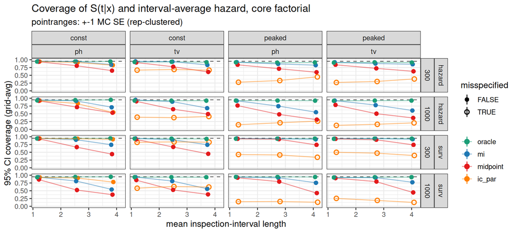

MI survival coverage across core cells: 0.540-0.950 (median 0.918). Midpoint: 0.376-0.937 (median 0.766).

## Fig 2: beta / logHR(t) coverage + paired MI−midpoint differences

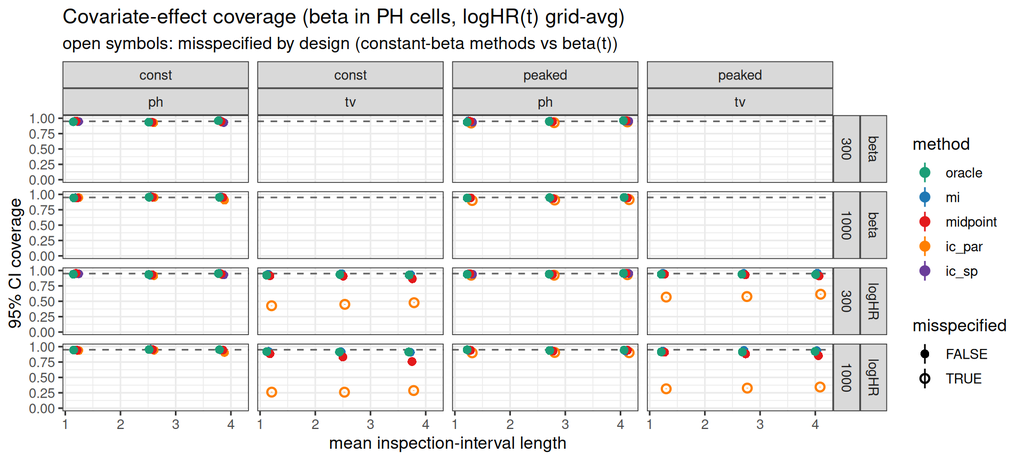

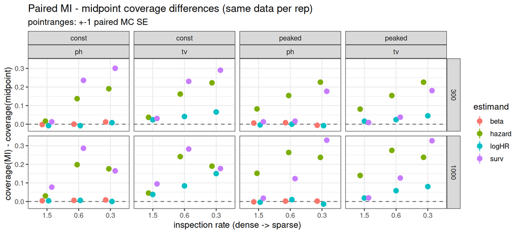

## Fig 3: point accuracy (RMSE, incl. Turnbull)

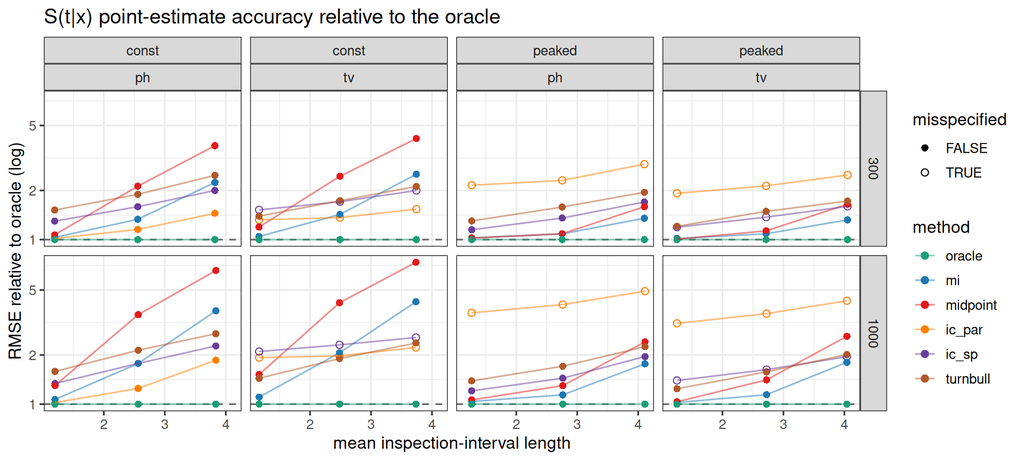

Median RRMSE vs oracle: MI 1.23, midpoint 1.55, Turnbull 1.71; Turnbull beats MI in 4/24 core cells (it is a step-function NPMLE without smoothing). Turnbull mean equivalence-class half-gap (scoring ambiguity) ranges 0.000-0.231 across core cells.

## Fig 4: CI width and avSE/empSE (the mechanism)

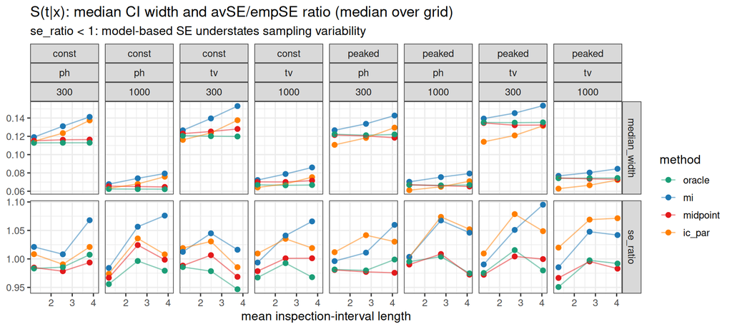

## Fig 5: time-varying effect recovery

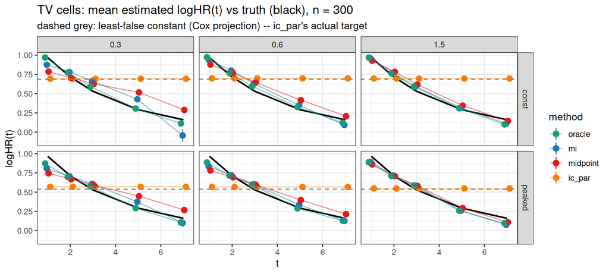

- const baseline: least-false constant logHR (exact-time convention): Cox 0.687, Weibull 0.695
- peaked baseline: least-false constant logHR (exact-time convention): Cox 0.539, Weibull 0.550

## Fig 6: competing risks, smooth f(x), m-sensitivity

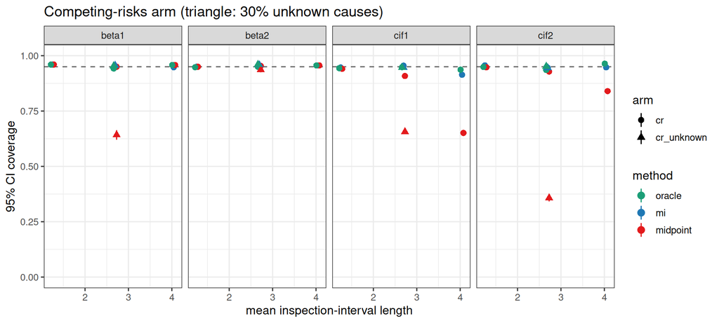

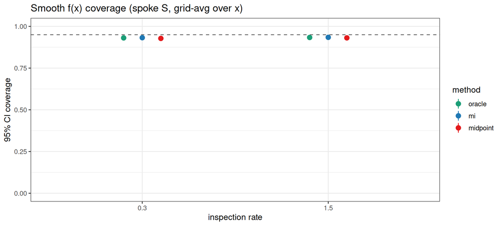

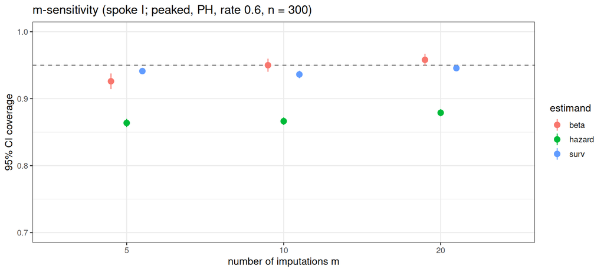

## Term-level summary tables

### beta

| cell_id | method | n_rep | coverage | be_coverage | bias | rmse | se_ratio | median_width | misspecified |
| --- | --- | --- | --- | --- | --- | --- | --- | --- | --- |
| core-const-ph-random-r0.3-n1000-m10 | ic_par | 500 | 0.906 (0.013) | 0.964 | 0.0443 (0.0035) | 0.0897 (0.0027) | 0.994 | 0.304 | FALSE |
| core-const-ph-random-r0.3-n1000-m10 | ic_sp | 500 | NA (NA) | NaN | 0.0293 (0.0034) | 0.0824 (0.0024) | NA | NA | FALSE |
| core-const-ph-random-r0.3-n1000-m10 | mi | 500 | 0.958 (0.009) | 0.956 | 0.0203 (0.0034) | 0.0784 (0.0023) | 1.035 | 0.306 | FALSE |
| core-const-ph-random-r0.3-n1000-m10 | midpoint | 500 | 0.950 (0.010) | 0.952 | -0.0238 (0.0032) | 0.0745 (0.0023) | 1.028 | 0.285 | FALSE |
| core-const-ph-random-r0.3-n1000-m10 | oracle | 500 | 0.952 (0.010) | 0.954 | 0.0027 (0.0030) | 0.0674 (0.0021) | 0.994 | 0.262 | FALSE |
| core-const-ph-random-r0.3-n300-m10 | ic_par | 500 | 0.934 (0.011) | 0.946 | 0.0445 (0.0063) | 0.1480 (0.0046) | 1.004 | 0.555 | FALSE |
| core-const-ph-random-r0.3-n300-m10 | ic_sp | 500 | 0.930 (0.011) | 0.950 | 0.0331 (0.0063) | 0.1454 (0.0045) | 1.041 | 0.574 | FALSE |
| core-const-ph-random-r0.3-n300-m10 | mi | 500 | 0.960 (0.009) | 0.970 | 0.0203 (0.0061) | 0.1385 (0.0042) | 1.048 | 0.562 | FALSE |
| core-const-ph-random-r0.3-n300-m10 | midpoint | 500 | 0.948 (0.010) | 0.958 | -0.0237 (0.0058) | 0.1318 (0.0040) | 1.025 | 0.520 | FALSE |
| core-const-ph-random-r0.3-n300-m10 | oracle | 500 | 0.960 (0.009) | 0.960 | 0.0016 (0.0052) | 0.1151 (0.0038) | 1.063 | 0.480 | FALSE |
| core-const-ph-random-r0.6-n1000-m10 | ic_par | 500 | 0.950 (0.010) | 0.950 | 0.0235 (0.0031) | 0.0724 (0.0023) | 1.033 | 0.277 | FALSE |
| core-const-ph-random-r0.6-n1000-m10 | ic_sp | 500 | NA (NA) | NaN | 0.0123 (0.0030) | 0.0685 (0.0021) | NA | NA | FALSE |
| core-const-ph-random-r0.6-n1000-m10 | mi | 500 | 0.962 (0.009) | 0.966 | 0.0094 (0.0030) | 0.0676 (0.0021) | 1.064 | 0.279 | FALSE |
| core-const-ph-random-r0.6-n1000-m10 | midpoint | 500 | 0.956 (0.009) | 0.960 | -0.0136 (0.0029) | 0.0662 (0.0020) | 1.056 | 0.268 | FALSE |
| core-const-ph-random-r0.6-n1000-m10 | oracle | 500 | 0.954 (0.009) | 0.956 | 0.0052 (0.0029) | 0.0646 (0.0020) | 1.038 | 0.262 | FALSE |
| core-const-ph-random-r0.6-n300-m10 | ic_par | 500 | 0.926 (0.012) | 0.928 | 0.0267 (0.0061) | 0.1393 (0.0045) | 0.948 | 0.508 | FALSE |
| core-const-ph-random-r0.6-n300-m10 | ic_sp | 500 | NA (NA) | NaN | 0.0181 (0.0060) | 0.1357 (0.0044) | NA | NA | FALSE |
| core-const-ph-random-r0.6-n300-m10 | mi | 500 | 0.934 (0.011) | 0.936 | 0.0133 (0.0060) | 0.1344 (0.0043) | 0.978 | 0.513 | FALSE |
| core-const-ph-random-r0.6-n300-m10 | midpoint | 500 | 0.934 (0.011) | 0.936 | -0.0115 (0.0057) | 0.1285 (0.0042) | 0.980 | 0.492 | FALSE |
| core-const-ph-random-r0.6-n300-m10 | oracle | 500 | 0.936 (0.011) | 0.940 | 0.0073 (0.0056) | 0.1247 (0.0041) | 0.985 | 0.480 | FALSE |
| core-const-ph-random-r1.5-n1000-m10 | ic_par | 500 | 0.948 (0.010) | 0.944 | 0.0092 (0.0031) | 0.0697 (0.0023) | 0.977 | 0.265 | FALSE |
| core-const-ph-random-r1.5-n1000-m10 | ic_sp | 500 | NA (NA) | NaN | 0.0035 (0.0031) | 0.0691 (0.0023) | NA | NA | FALSE |
| core-const-ph-random-r1.5-n1000-m10 | mi | 500 | 0.946 (0.010) | 0.944 | 0.0029 (0.0031) | 0.0688 (0.0023) | 0.987 | 0.266 | FALSE |
| core-const-ph-random-r1.5-n1000-m10 | midpoint | 500 | 0.942 (0.010) | 0.942 | -0.0030 (0.0030) | 0.0680 (0.0023) | 0.990 | 0.264 | FALSE |
| core-const-ph-random-r1.5-n1000-m10 | oracle | 500 | 0.944 (0.010) | 0.944 | 0.0014 (0.0031) | 0.0682 (0.0022) | 0.980 | 0.263 | FALSE |
| core-const-ph-random-r1.5-n300-m10 | ic_par | 500 | 0.948 (0.010) | 0.952 | 0.0081 (0.0056) | 0.1256 (0.0040) | 0.986 | 0.484 | FALSE |
| core-const-ph-random-r1.5-n300-m10 | ic_sp | 500 | 0.946 (0.010) | 0.946 | 0.0026 (0.0056) | 0.1249 (0.0039) | 1.013 | 0.493 | FALSE |
| core-const-ph-random-r1.5-n300-m10 | mi | 500 | 0.950 (0.010) | 0.952 | 0.0012 (0.0056) | 0.1243 (0.0039) | 1.001 | 0.488 | FALSE |
| core-const-ph-random-r1.5-n300-m10 | midpoint | 500 | 0.952 (0.010) | 0.948 | -0.0047 (0.0055) | 0.1233 (0.0039) | 0.999 | 0.483 | FALSE |
| core-const-ph-random-r1.5-n300-m10 | oracle | 500 | 0.942 (0.010) | 0.944 | 0.0010 (0.0055) | 0.1234 (0.0039) | 0.992 | 0.480 | FALSE |

[output cut: 75 more lines]

### hazard

| cell_id | method | n_rep | coverage | be_coverage | bias | rmse | se_ratio | median_width | misspecified |
| --- | --- | --- | --- | --- | --- | --- | --- | --- | --- |
| core-const-ph-random-r0.3-n1000-m10 | ic_par | 500 | 0.547 (0.010) | 0.949 | -0.0291 (0.0006) | 0.0418 (0.0005) | 9.96e-01 | 6.70e-02 | FALSE |
| core-const-ph-random-r0.3-n1000-m10 | mi | 500 | 0.709 (0.006) | 0.981 | -0.0118 (0.0006) | 0.0702 (0.0006) | 1.29e+00 | 1.38e-01 | FALSE |
| core-const-ph-random-r0.3-n1000-m10 | midpoint | 500 | 0.534 (0.006) | 0.955 | -0.0235 (0.0006) | 0.0959 (0.0005) | 1.03e+00 | 1.06e-01 | FALSE |
| core-const-ph-random-r0.3-n1000-m10 | oracle | 500 | 0.948 (0.005) | 0.949 | 0.0001 (0.0005) | 0.0201 (0.0004) | 9.73e-01 | 6.90e-02 | FALSE |
| core-const-ph-random-r0.3-n300-m10 | ic_par | 500 | 0.827 (0.010) | 0.946 | -0.0254 (0.0011) | 0.0492 (0.0008) | 1.01e+00 | 1.25e-01 | FALSE |
| core-const-ph-random-r0.3-n300-m10 | mi | 500 | 0.842 (0.005) | 0.980 | -0.0104 (0.0011) | 0.0821 (0.0010) | 1.27e+00 | 2.16e-01 | FALSE |
| core-const-ph-random-r0.3-n300-m10 | midpoint | 500 | 0.651 (0.006) | 0.955 | -0.0215 (0.0010) | 0.1045 (0.0010) | 1.02e+00 | 1.65e-01 | FALSE |
| core-const-ph-random-r0.3-n300-m10 | oracle | 500 | 0.945 (0.005) | 0.947 | 0.0032 (0.0009) | 0.0391 (0.0009) | 9.90e-01 | 1.27e-01 | FALSE |
| core-const-ph-random-r0.6-n1000-m10 | ic_par | 500 | 0.833 (0.009) | 0.950 | -0.0124 (0.0005) | 0.0242 (0.0004) | 1.02e+00 | 6.30e-02 | FALSE |
| core-const-ph-random-r0.6-n1000-m10 | mi | 500 | 0.912 (0.005) | 0.972 | 0.0046 (0.0006) | 0.0415 (0.0006) | 1.18e+00 | 1.33e-01 | FALSE |
| core-const-ph-random-r0.6-n1000-m10 | midpoint | 500 | 0.714 (0.005) | 0.950 | -0.0020 (0.0006) | 0.0504 (0.0005) | 1.01e+00 | 1.04e-01 | FALSE |
| core-const-ph-random-r0.6-n1000-m10 | oracle | 500 | 0.940 (0.005) | 0.941 | 0.0015 (0.0005) | 0.0218 (0.0005) | 9.49e-01 | 7.00e-02 | FALSE |
| core-const-ph-random-r0.6-n300-m10 | ic_par | 500 | 0.916 (0.007) | 0.937 | -0.0107 (0.0010) | 0.0375 (0.0008) | 9.76e-01 | 1.17e-01 | FALSE |
| core-const-ph-random-r0.6-n300-m10 | mi | 500 | 0.945 (0.004) | 0.966 | 0.0033 (0.0011) | 0.0590 (0.0010) | 1.18e+00 | 2.01e-01 | FALSE |
| core-const-ph-random-r0.6-n300-m10 | midpoint | 500 | 0.808 (0.005) | 0.949 | -0.0022 (0.0010) | 0.0670 (0.0009) | 1.02e+00 | 1.66e-01 | FALSE |
| core-const-ph-random-r0.6-n300-m10 | oracle | 500 | 0.943 (0.005) | 0.944 | 0.0029 (0.0009) | 0.0387 (0.0010) | 9.73e-01 | 1.26e-01 | FALSE |
| core-const-ph-random-r1.5-n1000-m10 | ic_par | 500 | 0.923 (0.007) | 0.938 | -0.0041 (0.0005) | 0.0189 (0.0004) | 9.70e-01 | 6.10e-02 | FALSE |
| core-const-ph-random-r1.5-n1000-m10 | mi | 500 | 0.950 (0.004) | 0.952 | 0.0016 (0.0006) | 0.0293 (0.0006) | 1.05e+00 | 9.90e-02 | FALSE |
| core-const-ph-random-r1.5-n1000-m10 | midpoint | 500 | 0.920 (0.005) | 0.930 | 0.0013 (0.0006) | 0.0314 (0.0005) | 9.44e-01 | 9.70e-02 | FALSE |
| core-const-ph-random-r1.5-n1000-m10 | oracle | 500 | 0.930 (0.005) | 0.930 | 0.0009 (0.0005) | 0.0217 (0.0005) | 9.19e-01 | 6.90e-02 | FALSE |
| core-const-ph-random-r1.5-n300-m10 | ic_par | 500 | 0.944 (0.006) | 0.943 | -0.0017 (0.0010) | 0.0329 (0.0007) | 1.00e+00 | 1.14e-01 | FALSE |
| core-const-ph-random-r1.5-n300-m10 | mi | 500 | 0.954 (0.004) | 0.957 | 0.0025 (0.0010) | 0.0433 (0.0009) | 1.07e+00 | 1.47e-01 | FALSE |
| core-const-ph-random-r1.5-n300-m10 | midpoint | 500 | 0.938 (0.005) | 0.941 | 0.0016 (0.0010) | 0.0453 (0.0010) | 9.79e-01 | 1.37e-01 | FALSE |
| core-const-ph-random-r1.5-n300-m10 | oracle | 500 | 0.942 (0.005) | 0.942 | 0.0038 (0.0009) | 0.0381 (0.0008) | 9.74e-01 | 1.25e-01 | FALSE |
| core-const-tv-random-r0.3-n1000-m10 | ic_par | 500 | 0.412 (0.003) | 0.935 | -0.0252 (0.0006) | 0.0535 (0.0003) | 9.46e-01 | 7.00e-02 | TRUE |
| core-const-tv-random-r0.3-n1000-m10 | mi | 500 | 0.681 (0.006) | 0.979 | -0.0071 (0.0006) | 0.0888 (0.0006) | 1.27e+00 | 1.60e-01 | FALSE |
| core-const-tv-random-r0.3-n1000-m10 | midpoint | 500 | 0.491 (0.005) | 0.941 | -0.0187 (0.0006) | 0.1305 (0.0006) | 9.90e-01 | 1.17e-01 | FALSE |
| core-const-tv-random-r0.3-n1000-m10 | oracle | 500 | 0.921 (0.005) | 0.931 | 0.0036 (0.0005) | 0.0288 (0.0006) | 9.24e-01 | 9.10e-02 | FALSE |
| core-const-tv-random-r0.3-n300-m10 | ic_par | 500 | 0.666 (0.007) | 0.919 | -0.0205 (0.0013) | 0.0646 (0.0010) | 9.69e-01 | 1.22e-01 | TRUE |
| core-const-tv-random-r0.3-n300-m10 | mi | 500 | 0.832 (0.005) | 0.968 | -0.0044 (0.0014) | 0.1116 (0.0046) | 1.24e+00 | 2.55e-01 | FALSE |

[output cut: 108 more lines]

### logHR

| cell_id | method | n_rep | coverage | be_coverage | bias | rmse | se_ratio | median_width | misspecified |
| --- | --- | --- | --- | --- | --- | --- | --- | --- | --- |
| core-const-ph-random-r0.3-n1000-m10 | ic_par | 500 | 0.906 (0.013) | 0.950 | 0.0443 (0.0035) | 0.0897 (0.0027) | 0.995 | 0.301 | FALSE |
| core-const-ph-random-r0.3-n1000-m10 | ic_sp | 500 | NA (NA) | NaN | 0.0293 (0.0034) | 0.0824 (0.0024) | NA | NA | FALSE |
| core-const-ph-random-r0.3-n1000-m10 | mi | 500 | 0.946 (0.010) | 0.958 | 0.0203 (0.0034) | 0.0784 (0.0023) | 1.034 | 0.302 | FALSE |
| core-const-ph-random-r0.3-n1000-m10 | midpoint | 500 | 0.946 (0.010) | 0.958 | -0.0238 (0.0032) | 0.0745 (0.0023) | 1.029 | 0.282 | FALSE |
| core-const-ph-random-r0.3-n1000-m10 | oracle | 500 | 0.952 (0.010) | 0.952 | 0.0027 (0.0030) | 0.0674 (0.0021) | 0.993 | 0.260 | FALSE |
| core-const-ph-random-r0.3-n300-m10 | ic_par | 500 | 0.932 (0.011) | 0.940 | 0.0445 (0.0063) | 0.1480 (0.0046) | 1.002 | 0.551 | FALSE |
| core-const-ph-random-r0.3-n300-m10 | ic_sp | 500 | 0.930 (0.011) | 0.950 | 0.0331 (0.0063) | 0.1454 (0.0045) | 1.041 | 0.574 | FALSE |
| core-const-ph-random-r0.3-n300-m10 | mi | 500 | 0.954 (0.009) | 0.954 | 0.0203 (0.0061) | 0.1385 (0.0042) | 1.050 | 0.558 | FALSE |
| core-const-ph-random-r0.3-n300-m10 | midpoint | 500 | 0.946 (0.010) | 0.958 | -0.0237 (0.0058) | 0.1318 (0.0040) | 1.023 | 0.514 | FALSE |
| core-const-ph-random-r0.3-n300-m10 | oracle | 500 | 0.952 (0.010) | 0.952 | 0.0016 (0.0052) | 0.1151 (0.0038) | 1.062 | 0.475 | FALSE |
| core-const-ph-random-r0.6-n1000-m10 | ic_par | 500 | 0.942 (0.010) | 0.950 | 0.0235 (0.0031) | 0.0724 (0.0023) | 1.036 | 0.275 | FALSE |
| core-const-ph-random-r0.6-n1000-m10 | ic_sp | 500 | NA (NA) | NaN | 0.0123 (0.0030) | 0.0685 (0.0021) | NA | NA | FALSE |
| core-const-ph-random-r0.6-n1000-m10 | mi | 500 | 0.958 (0.009) | 0.960 | 0.0094 (0.0030) | 0.0676 (0.0021) | 1.064 | 0.275 | FALSE |
| core-const-ph-random-r0.6-n1000-m10 | midpoint | 500 | 0.952 (0.010) | 0.962 | -0.0136 (0.0029) | 0.0662 (0.0020) | 1.054 | 0.266 | FALSE |
| core-const-ph-random-r0.6-n1000-m10 | oracle | 500 | 0.954 (0.009) | 0.948 | 0.0052 (0.0029) | 0.0646 (0.0020) | 1.038 | 0.260 | FALSE |
| core-const-ph-random-r0.6-n300-m10 | ic_par | 500 | 0.916 (0.012) | 0.924 | 0.0267 (0.0061) | 0.1393 (0.0045) | 0.948 | 0.503 | FALSE |
| core-const-ph-random-r0.6-n300-m10 | ic_sp | 500 | NA (NA) | NaN | 0.0181 (0.0060) | 0.1357 (0.0044) | NA | NA | FALSE |
| core-const-ph-random-r0.6-n300-m10 | mi | 500 | 0.924 (0.012) | 0.924 | 0.0133 (0.0060) | 0.1344 (0.0043) | 0.980 | 0.509 | FALSE |
| core-const-ph-random-r0.6-n300-m10 | midpoint | 500 | 0.932 (0.011) | 0.928 | -0.0115 (0.0057) | 0.1285 (0.0042) | 0.982 | 0.488 | FALSE |
| core-const-ph-random-r0.6-n300-m10 | oracle | 500 | 0.936 (0.011) | 0.940 | 0.0073 (0.0056) | 0.1247 (0.0041) | 0.983 | 0.474 | FALSE |
| core-const-ph-random-r1.5-n1000-m10 | ic_par | 500 | 0.938 (0.011) | 0.938 | 0.0092 (0.0031) | 0.0697 (0.0023) | 0.977 | 0.262 | FALSE |
| core-const-ph-random-r1.5-n1000-m10 | ic_sp | 500 | NA (NA) | NaN | 0.0035 (0.0031) | 0.0691 (0.0023) | NA | NA | FALSE |
| core-const-ph-random-r1.5-n1000-m10 | mi | 500 | 0.946 (0.010) | 0.942 | 0.0029 (0.0031) | 0.0688 (0.0023) | 0.987 | 0.263 | FALSE |
| core-const-ph-random-r1.5-n1000-m10 | midpoint | 500 | 0.942 (0.010) | 0.944 | -0.0030 (0.0030) | 0.0680 (0.0023) | 0.991 | 0.262 | FALSE |
| core-const-ph-random-r1.5-n1000-m10 | oracle | 500 | 0.946 (0.010) | 0.946 | 0.0014 (0.0031) | 0.0682 (0.0022) | 0.980 | 0.260 | FALSE |
| core-const-ph-random-r1.5-n300-m10 | ic_par | 500 | 0.946 (0.010) | 0.948 | 0.0081 (0.0056) | 0.1256 (0.0040) | 0.986 | 0.480 | FALSE |
| core-const-ph-random-r1.5-n300-m10 | ic_sp | 500 | 0.946 (0.010) | 0.946 | 0.0026 (0.0056) | 0.1249 (0.0039) | 1.013 | 0.493 | FALSE |
| core-const-ph-random-r1.5-n300-m10 | mi | 500 | 0.946 (0.010) | 0.950 | 0.0012 (0.0056) | 0.1243 (0.0039) | 1.000 | 0.482 | FALSE |
| core-const-ph-random-r1.5-n300-m10 | midpoint | 500 | 0.954 (0.009) | 0.952 | -0.0047 (0.0055) | 0.1233 (0.0039) | 0.999 | 0.478 | FALSE |
| core-const-ph-random-r1.5-n300-m10 | oracle | 500 | 0.940 (0.011) | 0.940 | 0.0010 (0.0055) | 0.1234 (0.0039) | 0.994 | 0.476 | FALSE |

[output cut: 135 more lines]

### surv

| cell_id | method | n_rep | coverage | be_coverage | bias | rmse | se_ratio | median_width | misspecified |
| --- | --- | --- | --- | --- | --- | --- | --- | --- | --- |
| core-const-ph-random-r0.3-n1000-m10 | ic_par | 500 | 0.783 (0.007) | 0.946 | 0.0064 (0.0006) | 0.0289 (0.0004) | 1.008 | 0.076 | FALSE |
| core-const-ph-random-r0.3-n1000-m10 | ic_sp | 500 | NA (NA) | NaN | 0.0025 (0.0008) | 0.0354 (0.0005) | NA | NA | FALSE |
| core-const-ph-random-r0.3-n1000-m10 | mi | 500 | 0.540 (0.005) | 0.957 | 0.0401 (0.0005) | 0.0580 (0.0005) | 1.076 | 0.079 | FALSE |
| core-const-ph-random-r0.3-n1000-m10 | midpoint | 500 | 0.376 (0.003) | 0.952 | 0.0782 (0.0004) | 0.1026 (0.0004) | 0.999 | 0.065 | FALSE |
| core-const-ph-random-r0.3-n1000-m10 | oracle | 500 | 0.949 (0.006) | 0.946 | 0.0006 (0.0005) | 0.0156 (0.0003) | 0.979 | 0.062 | FALSE |
| core-const-ph-random-r0.3-n1000-m10 | turnbull | 500 | NA (NA) | NaN | 0.0019 (0.0007) | 0.0420 (0.0005) | NA | NA | FALSE |
| core-const-ph-random-r0.3-n300-m10 | ic_par | 500 | 0.917 (0.006) | 0.954 | 0.0053 (0.0010) | 0.0400 (0.0007) | 1.021 | 0.137 | FALSE |
| core-const-ph-random-r0.3-n300-m10 | ic_sp | 500 | NA (NA) | NaN | 0.0011 (0.0012) | 0.0552 (0.0008) | NA | NA | FALSE |
| core-const-ph-random-r0.3-n300-m10 | mi | 500 | 0.741 (0.007) | 0.960 | 0.0385 (0.0009) | 0.0618 (0.0008) | 1.068 | 0.141 | FALSE |
| core-const-ph-random-r0.3-n300-m10 | midpoint | 500 | 0.440 (0.004) | 0.952 | 0.0768 (0.0008) | 0.1038 (0.0007) | 0.994 | 0.116 | FALSE |
| core-const-ph-random-r0.3-n300-m10 | oracle | 500 | 0.949 (0.005) | 0.950 | 0.0009 (0.0008) | 0.0276 (0.0006) | 1.007 | 0.113 | FALSE |
| core-const-ph-random-r0.3-n300-m10 | turnbull | 500 | NA (NA) | NaN | 0.0008 (0.0012) | 0.0683 (0.0007) | NA | NA | FALSE |
| core-const-ph-random-r0.6-n1000-m10 | ic_par | 500 | 0.912 (0.006) | 0.953 | 0.0027 (0.0005) | 0.0191 (0.0003) | 1.036 | 0.068 | FALSE |
| core-const-ph-random-r0.6-n1000-m10 | ic_sp | 500 | NA (NA) | NaN | -0.0001 (0.0007) | 0.0271 (0.0004) | NA | NA | FALSE |
| core-const-ph-random-r0.6-n1000-m10 | mi | 500 | 0.810 (0.005) | 0.958 | 0.0118 (0.0005) | 0.0271 (0.0003) | 1.057 | 0.074 | FALSE |
| core-const-ph-random-r0.6-n1000-m10 | midpoint | 500 | 0.524 (0.006) | 0.955 | 0.0380 (0.0004) | 0.0540 (0.0004) | 1.024 | 0.065 | FALSE |
| core-const-ph-random-r0.6-n1000-m10 | oracle | 500 | 0.944 (0.006) | 0.947 | -0.0004 (0.0005) | 0.0153 (0.0003) | 0.996 | 0.062 | FALSE |
| core-const-ph-random-r0.6-n1000-m10 | turnbull | 500 | NA (NA) | NaN | -0.0005 (0.0006) | 0.0327 (0.0004) | NA | NA | FALSE |
| core-const-ph-random-r0.6-n300-m10 | ic_par | 500 | 0.935 (0.006) | 0.945 | 0.0037 (0.0009) | 0.0324 (0.0007) | 0.990 | 0.123 | FALSE |
| core-const-ph-random-r0.6-n300-m10 | ic_sp | 500 | NA (NA) | NaN | 0.0010 (0.0010) | 0.0446 (0.0007) | NA | NA | FALSE |
| core-const-ph-random-r0.6-n300-m10 | mi | 500 | 0.902 (0.006) | 0.949 | 0.0126 (0.0009) | 0.0374 (0.0006) | 1.008 | 0.131 | FALSE |
| core-const-ph-random-r0.6-n300-m10 | midpoint | 500 | 0.666 (0.006) | 0.945 | 0.0389 (0.0008) | 0.0596 (0.0007) | 0.978 | 0.116 | FALSE |
| core-const-ph-random-r0.6-n300-m10 | oracle | 500 | 0.947 (0.006) | 0.948 | 0.0008 (0.0008) | 0.0281 (0.0006) | 0.986 | 0.113 | FALSE |
| core-const-ph-random-r0.6-n300-m10 | turnbull | 500 | NA (NA) | NaN | 0.0003 (0.0010) | 0.0532 (0.0006) | NA | NA | FALSE |
| core-const-ph-random-r1.5-n1000-m10 | ic_par | 500 | 0.931 (0.006) | 0.938 | 0.0015 (0.0005) | 0.0162 (0.0003) | 0.974 | 0.063 | FALSE |
| core-const-ph-random-r1.5-n1000-m10 | ic_sp | 500 | NA (NA) | NaN | -0.0004 (0.0005) | 0.0213 (0.0004) | NA | NA | FALSE |
| core-const-ph-random-r1.5-n1000-m10 | mi | 500 | 0.938 (0.005) | 0.942 | 0.0009 (0.0005) | 0.0170 (0.0003) | 0.984 | 0.068 | FALSE |
| core-const-ph-random-r1.5-n1000-m10 | midpoint | 500 | 0.861 (0.007) | 0.939 | 0.0084 (0.0005) | 0.0207 (0.0003) | 0.967 | 0.066 | FALSE |
| core-const-ph-random-r1.5-n1000-m10 | oracle | 500 | 0.934 (0.006) | 0.935 | 0.0001 (0.0005) | 0.0159 (0.0003) | 0.956 | 0.062 | FALSE |
| core-const-ph-random-r1.5-n1000-m10 | turnbull | 500 | NA (NA) | NaN | -0.0003 (0.0005) | 0.0252 (0.0003) | NA | NA | FALSE |

[output cut: 174 more lines]

### beta1

| cell_id | method | n_rep | coverage | be_coverage | bias | rmse | se_ratio | median_width | misspecified |
| --- | --- | --- | --- | --- | --- | --- | --- | --- | --- |
| cr-cr-cr-random-r0.3-n450-m10 | mi | 498 | 0.948 (0.010) | 0.948 | -0.0006 (0.0069) | 0.1529 (0.0050) | 1.017 | 0.609 | FALSE |
| cr-cr-cr-random-r0.3-n450-m10 | midpoint | 500 | 0.958 (0.009) | 0.952 | -0.0061 (0.0068) | 0.1514 (0.0049) | 1.020 | 0.604 | FALSE |
| cr-cr-cr-random-r0.3-n450-m10 | oracle | 500 | 0.958 (0.009) | 0.958 | -0.0007 (0.0061) | 0.1369 (0.0044) | 1.013 | 0.543 | FALSE |
| cr-cr-cr-random-r0.6-n450-m10 | mi | 499 | 0.948 (0.010) | 0.948 | 0.0061 (0.0065) | 0.1445 (0.0044) | 1.003 | 0.567 | FALSE |
| cr-cr-cr-random-r0.6-n450-m10 | midpoint | 500 | 0.950 (0.010) | 0.950 | 0.0022 (0.0064) | 0.1438 (0.0044) | 1.002 | 0.565 | FALSE |
| cr-cr-cr-random-r0.6-n450-m10 | oracle | 500 | 0.942 (0.010) | 0.944 | 0.0030 (0.0062) | 0.1385 (0.0043) | 1.001 | 0.543 | FALSE |
| cr-cr-cr-random-r1.5-n450-m10 | mi | 500 | 0.960 (0.009) | 0.962 | 0.0006 (0.0064) | 0.1426 (0.0050) | 0.984 | 0.549 | FALSE |
| cr-cr-cr-random-r1.5-n450-m10 | midpoint | 500 | 0.960 (0.009) | 0.960 | -0.0003 (0.0064) | 0.1425 (0.0050) | 0.983 | 0.548 | FALSE |
| cr-cr-cr-random-r1.5-n450-m10 | oracle | 500 | 0.960 (0.009) | 0.960 | 0.0012 (0.0062) | 0.1392 (0.0047) | 0.994 | 0.542 | FALSE |
| cr_unknown-cr-cr-random-r0.6-n450-m10-mask | mi | 500 | 0.956 (0.009) | 0.960 | -0.0236 (0.0071) | 0.1595 (0.0047) | 1.007 | 0.619 | FALSE |
| cr_unknown-cr-cr-random-r0.6-n450-m10-mask | midpoint | 500 | 0.642 (0.021) | 0.942 | -0.1950 (0.0061) | 0.2379 (0.0052) | 0.952 | 0.507 | FALSE |
| cr_unknown-cr-cr-random-r0.6-n450-m10-mask | oracle | 500 | 0.954 (0.009) | 0.954 | 0.0081 (0.0064) | 0.1433 (0.0045) | 0.970 | 0.544 | FALSE |

### beta2

| cell_id | method | n_rep | coverage | be_coverage | bias | rmse | se_ratio | median_width | misspecified |
| --- | --- | --- | --- | --- | --- | --- | --- | --- | --- |
| cr-cr-cr-random-r0.3-n450-m10 | mi | 498 | 0.956 (0.009) | 0.950 | -0.0160 (0.0090) | 0.2008 (0.0072) | 1.005 | 0.785 | FALSE |
| cr-cr-cr-random-r0.3-n450-m10 | midpoint | 500 | 0.956 (0.009) | 0.952 | -0.0222 (0.0089) | 0.2000 (0.0072) | 1.008 | 0.781 | FALSE |
| cr-cr-cr-random-r0.3-n450-m10 | oracle | 500 | 0.956 (0.009) | 0.954 | -0.0040 (0.0071) | 0.1580 (0.0056) | 1.042 | 0.644 | FALSE |
| cr-cr-cr-random-r0.6-n450-m10 | mi | 499 | 0.956 (0.009) | 0.956 | -0.0065 (0.0080) | 0.1781 (0.0054) | 1.013 | 0.703 | FALSE |
| cr-cr-cr-random-r0.6-n450-m10 | midpoint | 500 | 0.954 (0.009) | 0.956 | -0.0098 (0.0079) | 0.1777 (0.0054) | 1.013 | 0.701 | FALSE |
| cr-cr-cr-random-r0.6-n450-m10 | oracle | 500 | 0.950 (0.010) | 0.950 | -0.0060 (0.0073) | 0.1625 (0.0054) | 1.008 | 0.639 | FALSE |
| cr-cr-cr-random-r1.5-n450-m10 | mi | 500 | 0.950 (0.010) | 0.952 | -0.0080 (0.0075) | 0.1687 (0.0051) | 1.009 | 0.666 | FALSE |
| cr-cr-cr-random-r1.5-n450-m10 | midpoint | 500 | 0.950 (0.010) | 0.952 | -0.0087 (0.0075) | 0.1686 (0.0051) | 1.009 | 0.665 | FALSE |
| cr-cr-cr-random-r1.5-n450-m10 | oracle | 500 | 0.948 (0.010) | 0.948 | -0.0071 (0.0072) | 0.1609 (0.0051) | 1.019 | 0.641 | FALSE |
| cr_unknown-cr-cr-random-r0.6-n450-m10-mask | mi | 500 | 0.958 (0.009) | 0.968 | 0.0673 (0.0083) | 0.1965 (0.0060) | 1.086 | 0.783 | FALSE |
| cr_unknown-cr-cr-random-r0.6-n450-m10-mask | midpoint | 500 | 0.936 (0.011) | 0.940 | -0.0131 (0.0100) | 0.2238 (0.0074) | 0.966 | 0.844 | FALSE |
| cr_unknown-cr-cr-random-r0.6-n450-m10-mask | oracle | 500 | 0.960 (0.009) | 0.956 | -0.0050 (0.0071) | 0.1597 (0.0050) | 1.029 | 0.641 | FALSE |

### cif1

| cell_id | method | n_rep | coverage | be_coverage | bias | rmse | se_ratio | median_width | misspecified |
| --- | --- | --- | --- | --- | --- | --- | --- | --- | --- |
| cr-cr-cr-random-r0.3-n450-m10 | mi | 498 | 0.914 (0.008) | 0.955 | -0.0131 (0.0007) | 0.0240 (0.0005) | 1.068 | 0.080 | FALSE |
| cr-cr-cr-random-r0.3-n450-m10 | midpoint | 500 | 0.651 (0.012) | 0.950 | -0.0202 (0.0006) | 0.0293 (0.0005) | 0.976 | 0.067 | FALSE |
| cr-cr-cr-random-r0.3-n450-m10 | oracle | 500 | 0.937 (0.007) | 0.945 | 0.0024 (0.0007) | 0.0185 (0.0005) | 0.976 | 0.070 | FALSE |
| cr-cr-cr-random-r0.6-n450-m10 | mi | 499 | 0.955 (0.006) | 0.958 | -0.0029 (0.0007) | 0.0188 (0.0005) | 1.056 | 0.078 | FALSE |
| cr-cr-cr-random-r0.6-n450-m10 | midpoint | 500 | 0.908 (0.008) | 0.955 | -0.0068 (0.0006) | 0.0196 (0.0005) | 0.998 | 0.069 | FALSE |
| cr-cr-cr-random-r0.6-n450-m10 | oracle | 500 | 0.948 (0.007) | 0.954 | 0.0011 (0.0007) | 0.0175 (0.0005) | 1.029 | 0.071 | FALSE |
| cr-cr-cr-random-r1.5-n450-m10 | mi | 500 | 0.947 (0.006) | 0.952 | 0.0005 (0.0007) | 0.0184 (0.0005) | 1.012 | 0.073 | FALSE |
| cr-cr-cr-random-r1.5-n450-m10 | midpoint | 500 | 0.941 (0.006) | 0.948 | 0.0013 (0.0007) | 0.0184 (0.0005) | 0.996 | 0.070 | FALSE |
| cr-cr-cr-random-r1.5-n450-m10 | oracle | 500 | 0.944 (0.007) | 0.952 | 0.0025 (0.0007) | 0.0182 (0.0005) | 0.990 | 0.071 | FALSE |
| cr_unknown-cr-cr-random-r0.6-n450-m10-mask | mi | 500 | 0.946 (0.007) | 0.960 | -0.0071 (0.0007) | 0.0211 (0.0006) | 1.082 | 0.082 | FALSE |
| cr_unknown-cr-cr-random-r0.6-n450-m10-mask | midpoint | 500 | 0.656 (0.010) | 0.948 | 0.0260 (0.0008) | 0.0412 (0.0007) | 0.921 | 0.073 | FALSE |
| cr_unknown-cr-cr-random-r0.6-n450-m10-mask | oracle | 500 | 0.946 (0.007) | 0.947 | 0.0016 (0.0007) | 0.0180 (0.0005) | 0.998 | 0.071 | FALSE |

### cif2

| cell_id | method | n_rep | coverage | be_coverage | bias | rmse | se_ratio | median_width | misspecified |
| --- | --- | --- | --- | --- | --- | --- | --- | --- | --- |
| cr-cr-cr-random-r0.3-n450-m10 | mi | 498 | 0.947 (0.007) | 0.964 | -0.0055 (0.0005) | 0.0146 (0.0003) | 1.169 | 0.055 | FALSE |
| cr-cr-cr-random-r0.3-n450-m10 | midpoint | 500 | 0.840 (0.009) | 0.961 | -0.0065 (0.0004) | 0.0150 (0.0003) | 1.110 | 0.045 | FALSE |
| cr-cr-cr-random-r0.3-n450-m10 | oracle | 500 | 0.964 (0.007) | 0.965 | 0.0000 (0.0004) | 0.0114 (0.0003) | 1.068 | 0.043 | FALSE |
| cr-cr-cr-random-r0.6-n450-m10 | mi | 499 | 0.946 (0.007) | 0.944 | -0.0001 (0.0005) | 0.0142 (0.0004) | 0.979 | 0.051 | FALSE |
| cr-cr-cr-random-r0.6-n450-m10 | midpoint | 500 | 0.928 (0.008) | 0.942 | 0.0000 (0.0005) | 0.0140 (0.0004) | 0.972 | 0.047 | FALSE |
| cr-cr-cr-random-r0.6-n450-m10 | oracle | 500 | 0.936 (0.010) | 0.936 | 0.0010 (0.0005) | 0.0128 (0.0004) | 0.943 | 0.043 | FALSE |
| cr-cr-cr-random-r1.5-n450-m10 | mi | 500 | 0.956 (0.007) | 0.956 | 0.0002 (0.0005) | 0.0129 (0.0003) | 1.019 | 0.047 | FALSE |
| cr-cr-cr-random-r1.5-n450-m10 | midpoint | 500 | 0.948 (0.007) | 0.947 | 0.0012 (0.0005) | 0.0128 (0.0003) | 1.009 | 0.046 | FALSE |
| cr-cr-cr-random-r1.5-n450-m10 | oracle | 500 | 0.949 (0.009) | 0.949 | 0.0004 (0.0005) | 0.0124 (0.0003) | 0.996 | 0.043 | FALSE |
| cr_unknown-cr-cr-random-r0.6-n450-m10-mask | mi | 500 | 0.945 (0.007) | 0.967 | 0.0053 (0.0005) | 0.0158 (0.0004) | 1.146 | 0.060 | FALSE |
| cr_unknown-cr-cr-random-r0.6-n450-m10-mask | midpoint | 500 | 0.357 (0.015) | 0.956 | -0.0280 (0.0005) | 0.0347 (0.0005) | 0.858 | 0.039 | FALSE |
| cr_unknown-cr-cr-random-r0.6-n450-m10-mask | oracle | 500 | 0.952 (0.008) | 0.954 | 0.0005 (0.0005) | 0.0122 (0.0003) | 1.015 | 0.043 | FALSE |

### f_x

| cell_id | method | n_rep | coverage | be_coverage | bias | rmse | se_ratio | median_width | misspecified |
| --- | --- | --- | --- | --- | --- | --- | --- | --- | --- |
| smooth-peaked-smooth-random-r0.3-n300-m10 | mi | 500 | 0.932 (0.006) | 0.942 | -0.0000 (0.0000) | 0.2080 (0.0041) | 0.986 | 0.679 | FALSE |
| smooth-peaked-smooth-random-r0.3-n300-m10 | midpoint | 500 | 0.928 (0.006) | 0.937 | -0.0000 (0.0000) | 0.2070 (0.0040) | 0.975 | 0.664 | FALSE |
| smooth-peaked-smooth-random-r0.3-n300-m10 | oracle | 500 | 0.931 (0.006) | 0.941 | -0.0000 (0.0000) | 0.1853 (0.0035) | 0.976 | 0.612 | FALSE |
| smooth-peaked-smooth-random-r1.5-n300-m10 | mi | 500 | 0.934 (0.005) | 0.949 | -0.0000 (0.0000) | 0.1805 (0.0031) | 1.008 | 0.612 | FALSE |
| smooth-peaked-smooth-random-r1.5-n300-m10 | midpoint | 500 | 0.931 (0.006) | 0.945 | -0.0000 (0.0000) | 0.1810 (0.0031) | 0.999 | 0.610 | FALSE |
| smooth-peaked-smooth-random-r1.5-n300-m10 | oracle | 500 | 0.933 (0.005) | 0.950 | -0.0000 (0.0000) | 0.1774 (0.0031) | 1.013 | 0.603 | FALSE |

## Session / run metadata

- raw rows: 2246967
- max reps/cell: 500
- median fit times by method (s): oracle 0.7, mi 7.8, midpoint 0.8, ic_par 0.2, ic_sp 0.2, turnbull 0.0